# Лабораторная работа № 3

Daisyworld: популяции и температура

Куокконен Дарина Андреевна

Российский университет дружбы народов имени Патриса Лумумбы

НФИбд-01-23

2026-08-31

## Daisyworld связывает растения и среду

Цель — исследовать, как альбедо растений меняет температуру и условия их собственного размножения.

- построить пространственные состояния и анимацию;
- проследить численности на 1000 шагах;
- изменить солнечную светимость;
- сравнить четыре набора параметров;
- выполнить семь самостоятельных Julia-сценариев;
- включить производные QMD и листинги в отчёт.

## Альбедо определяет поглощение энергии

$$E=(1-a)L$$

$$T_{loc}=72\ln E+80$$

$$T\leftarrow(T+T_{loc})/2$$

Чёрные маргаритки нагревают поверхность сильнее белых.  
Температура обновляется на месте, как в коде практикума.  
Границы поля периодические.

**30 × 30** — решётка

**0,25 / 0,75** — альбедо видов

## Температура влияет на появление потомства

$$p(T)=\operatorname{clamp}(f(T),0,1)$$

$$f(T)=0{,}1457T-0{,}0032T^2-0{,}6443$$

Возраст ≥ `max_age` → гибель.

Потомок занимает свободного соседа.

В начале — по 180 растений каждого вида.  
Потомок наследует вид и альбедо.  
Саморегуляция возникает из обратной связи, а не из заданной температуры.

**25** — предельный возраст

**165** — seed модели

## Семь сценариев используют одно окружение

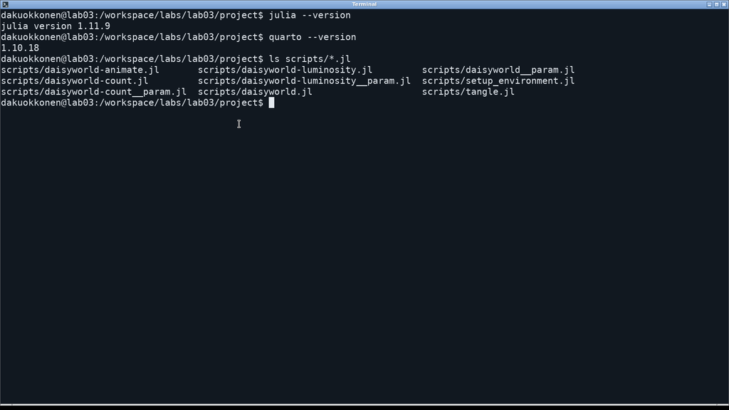

Julia 1.11.9  
Agents.jl  
CairoMakie  
DrWatson.jl  
Literate.jl и IJulia  
Project.toml  
Manifest.toml

## Общий модуль задаёт все правила модели

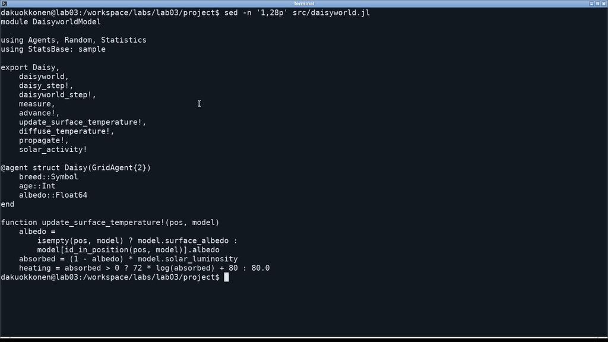

src/daisyworld.jl

- инициализация
- старение
- нагрев
- диффузия
- размножение
- светимость  
  Один генератор случайных чисел модели.

## К шагу 45 поле почти полностью занято

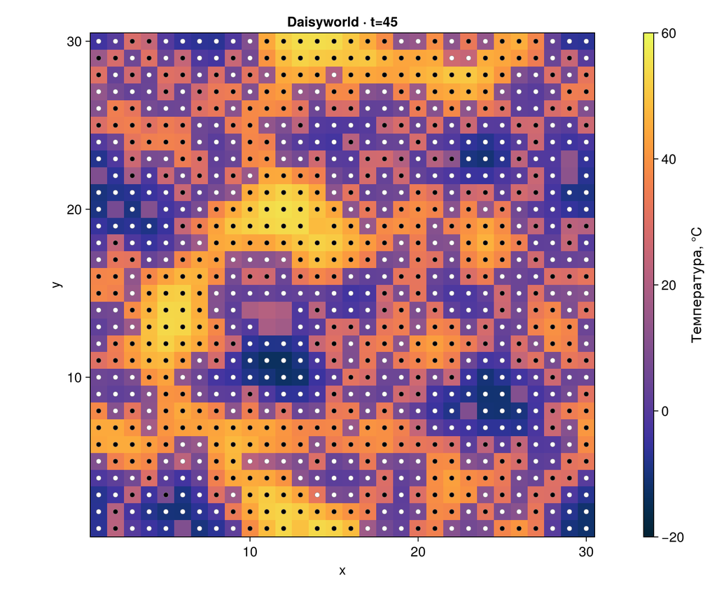

**450** — чёрных маргариток

**435** — белых маргариток

**20,13** — средняя температура

Пять шагов, затем ещё сорок: t = 45.

## При L = 1 оба вида сохраняются

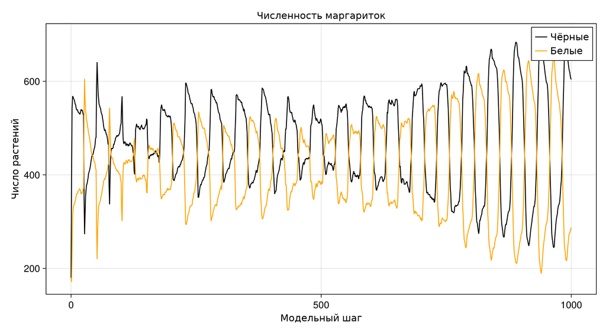

1000 шагов  
Чёрных: 604  
Белых: 287  
Температура: 34,75

Численности колеблются. Одна конечная точка не является стационарным решением.

## Рост светимости вытесняет чёрные растения

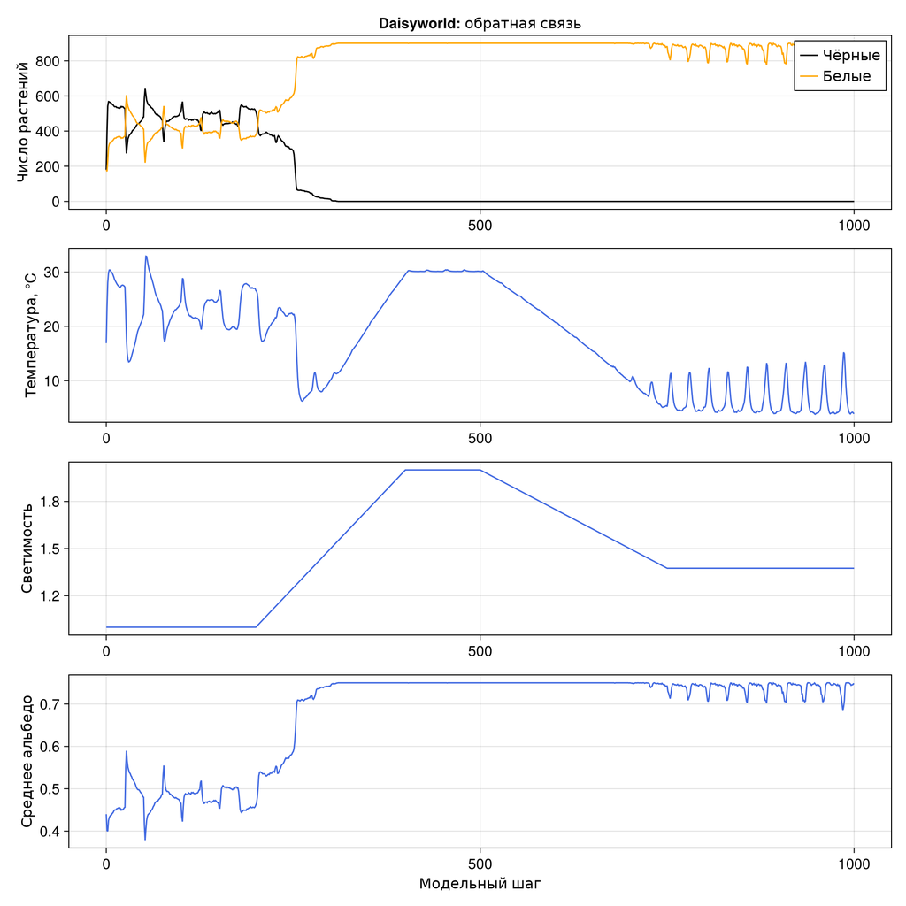

L: 1 → 2 → 1,375  
Чёрные исчезают:  
t = 310  
В конце: 892 белых

После исчезновения вид не восстанавливается: внешнего заселения в модели нет.

## Начальная доля и возраст меняют структуру поля

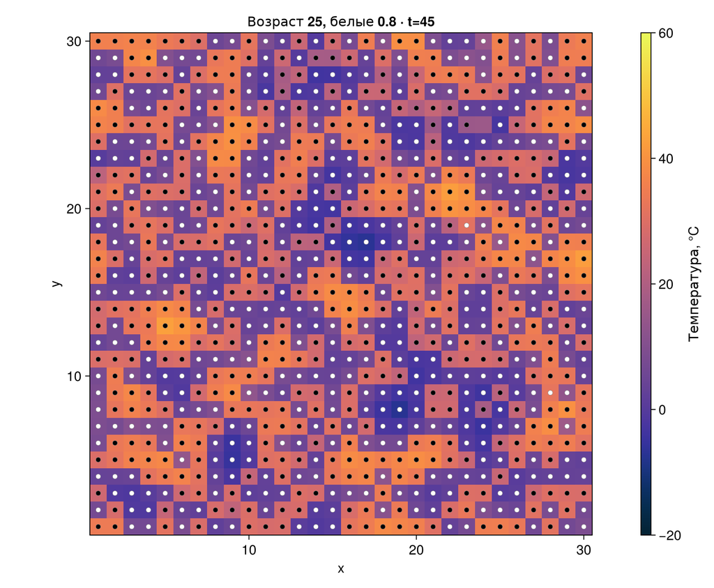

Возраст 25; белых в начале 80%

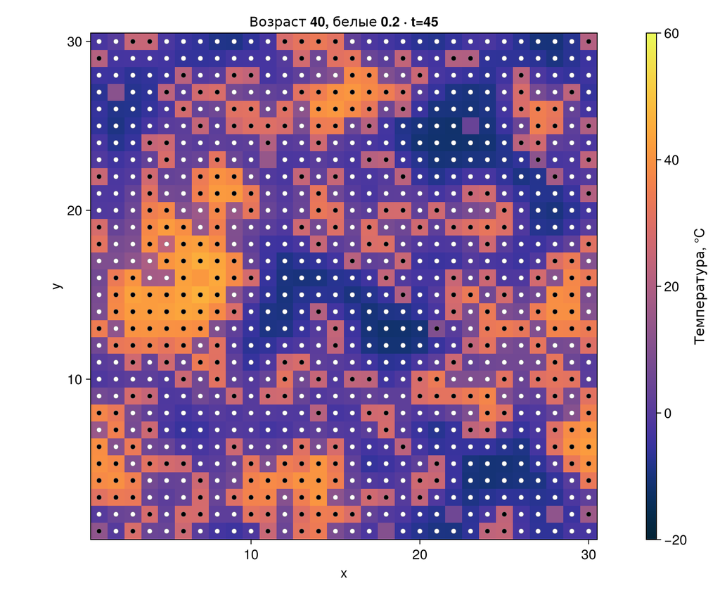

Возраст 40; белых в начале 20%

## Четыре опыта сохраняют сосуществование при L = 1

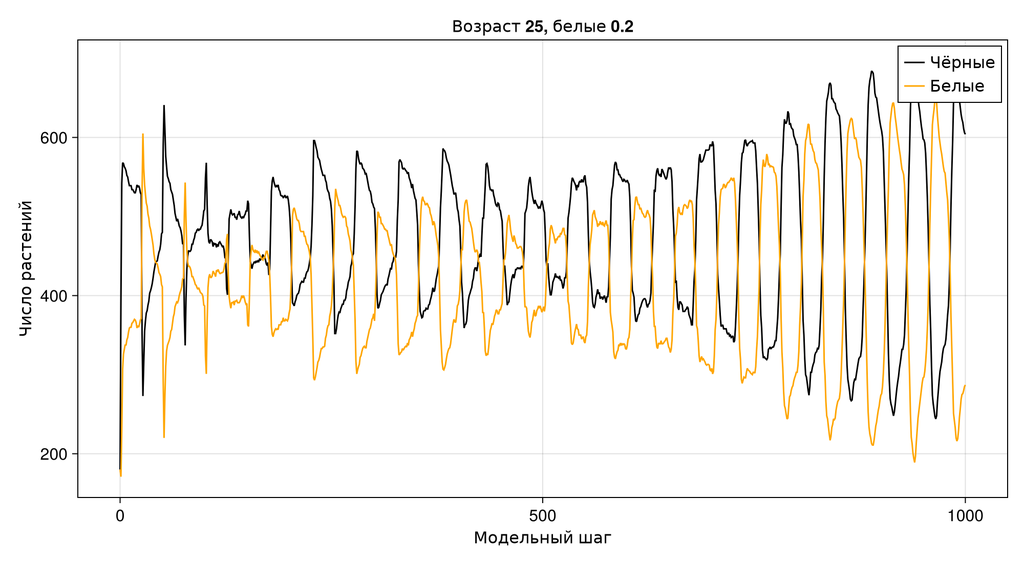

Возраст 25; белых в начале 20%

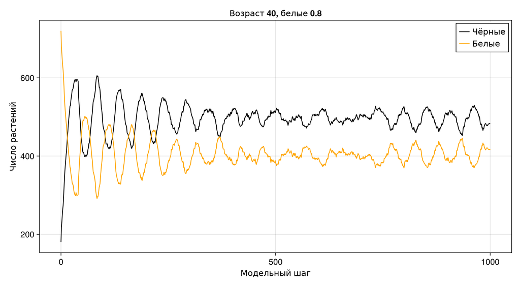

Возраст 40; белых в начале 80%

## Конечные численности зависят от параметров

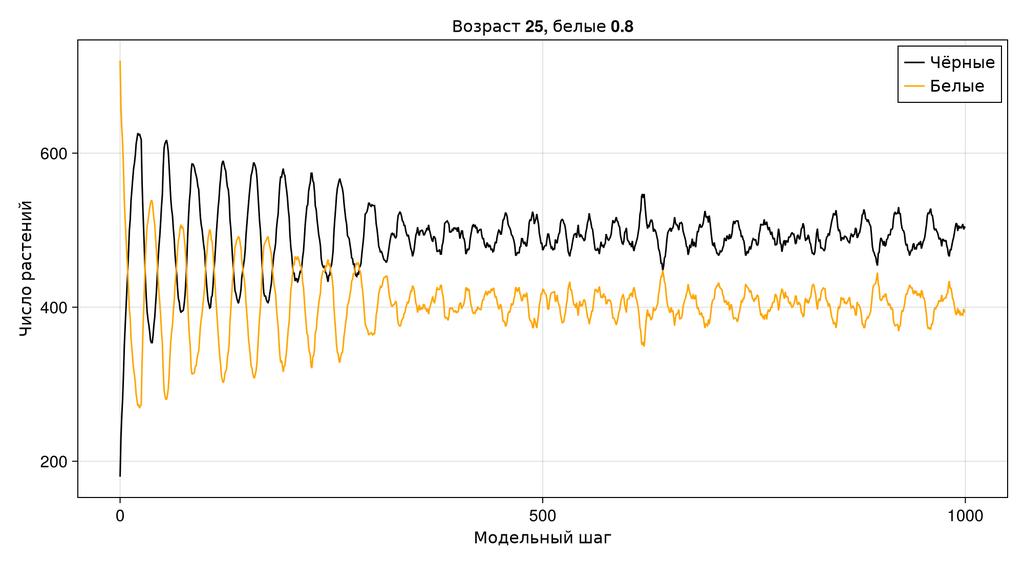

| Возраст | Белые₀ | Ч/Б |
| --- | --- | --- |
| 25 | 0,2 | 604/287 |
| 25 | 0,8 | 503/394 |
| 40 | 0,2 | 498/393 |
| 40 | 0,8 | 483/416 |

Один seed на набор: устойчивость результата для ансамбля миров не оценивалась.

## В ramp чёрные исчезают во всех четырёх опытах

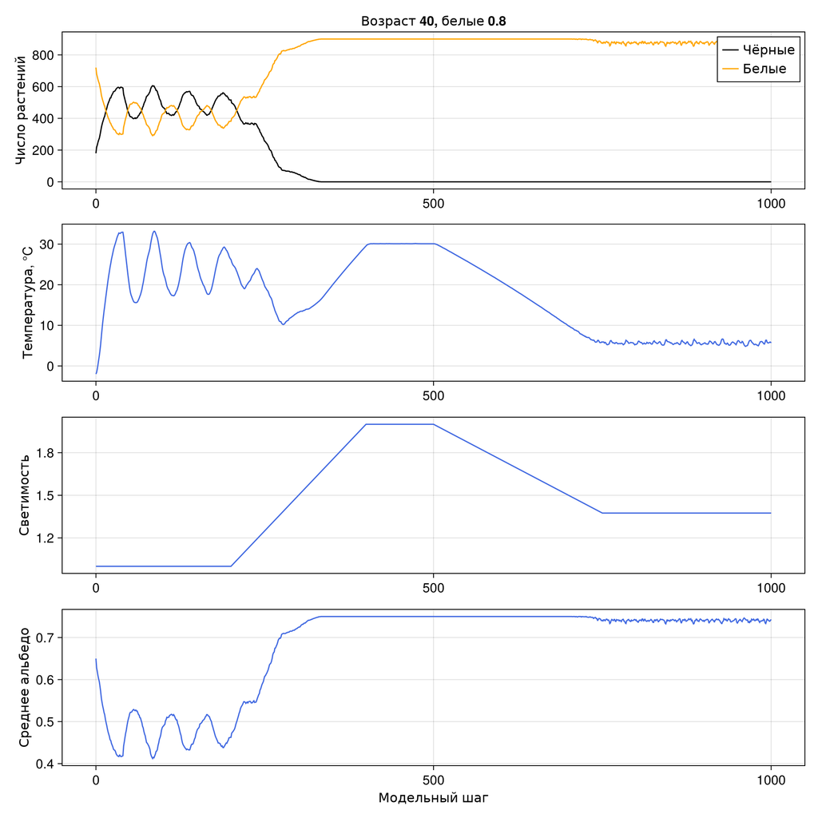

Белых при t = 1000:  
25 / 0,2 → 892  
25 / 0,8 → 864  
40 / 0,2 → 892  
40 / 0,8 → 882  
Возраст / доля белых в начале.

## Анимация сохраняет последовательность состояний

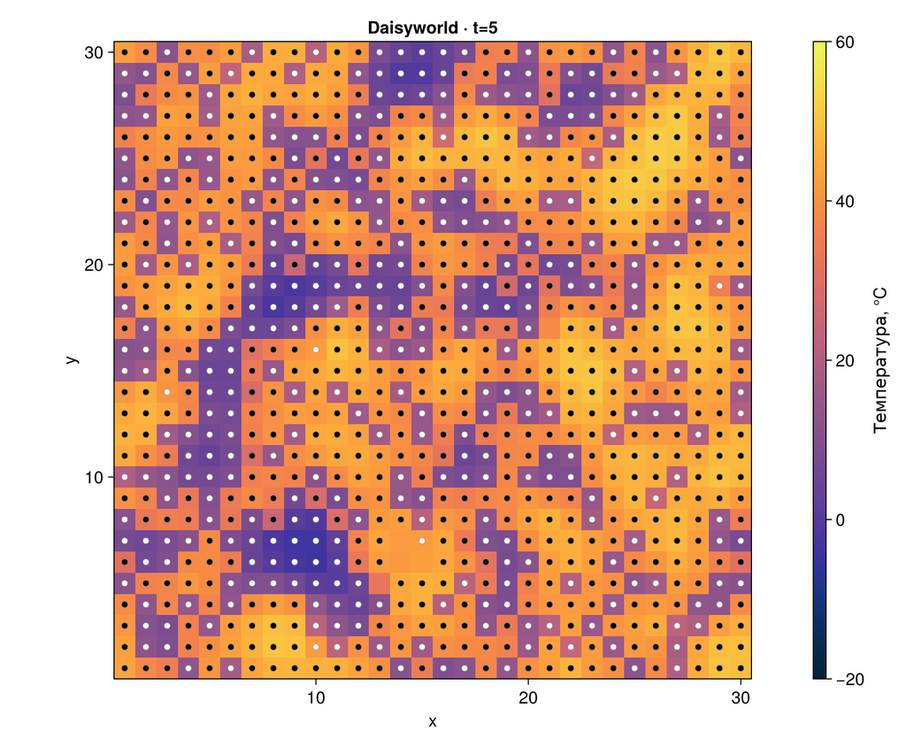

60 кадров: t = 0…59  
10 кадров/с  
image/01-animation.gif  
В frames.csv сохранены время и численности каждого кадра.

## 19 тестов проверяют правила и повторяемость

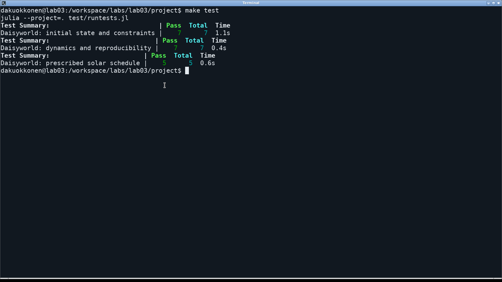

7 — инициализация  
7 — динамика и seed  
5 — светимость  
✓ вместимость решётки  
✓ возраст и температура  
✓ повторяемость траектории  
✓ границы ramp

## Из каждого сценария получены все форматы

```bash
make tangle
make run
make notebooks
make docs
make test
```

Семь литературных исходников

- чистый Julia-код;
- семь выполненных IPYNB;
- QMD и HTML-документация;
- 25 рисунков и анимация;
- CSV временных рядов;
- отчёт DOCX и PDF;
- презентация HTML и PPTX.

## Обратная связь меняет состав популяции

- При постоянной светимости сохраняются оба вида.
- Рост светимости приводит к исчезновению чёрных растений.
- Возраст и начальный состав меняют численные траектории.
- Семь сценариев покрывают главу 3 практикума.
- Выводы ограничены выбранной сеткой и одним seed.